# Visualizing the MRI readout

These calculations are designed to help visualize why the MRI signal (voltage) over time informs us about the amplitudes of the Fourier series.

## Contents

- Consider the signal across space

To begin, consider the signals we expect to see from a collection of beakers. (The course video already analyzed the case of just two beakers).

First, let's suppose that all the beakers are exactly the same.

When we turn on a spatial gradient, each beaker will produce a harmonic (sinusoid) at a slightly different frequency. (You know why?)

We are to read the signals over a brief period of time, so that the sinusoid is essentially constant amplitude as we read out the signal.

Here are a set of harmonics at different frequencies.

Let's suppose there are about 30 beakers

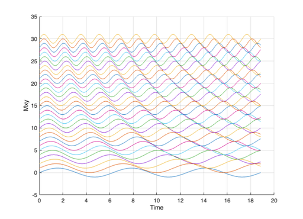

```matlab
f = (1:.1:4);                 % The Larmor frequency ranges from 1 to 4 Hz
t = (0:255)/255 * 2*pi*3;     % Time points we sample are over 6*pi
sig = zeros(numel(f),numel(t));
for ii=1:numel(f)
    sig(ii,:) = sin(t*f(ii));
end

% Remember that the times run from 0 to 6*pi, which is about 18.
mrvNewGraphWin;
hold on
for ii=1:numel(f)
    plot(t,sig(ii,:)+(ii-1));
end
grid on; xlabel('Time'); ylabel('Mxy');
```

**Question:** I plotted the curves displaced with respect to the vertical axis, just for clarity. Can you tell which signals come from the beakers on the right, and which from the beakers on the left?

## Consider the signal across space

Let's pick a point in time, say 35 time steps in. What will the amplitude of the harmonic be for each of the 31 beakers? The amplitude over space looks like this.

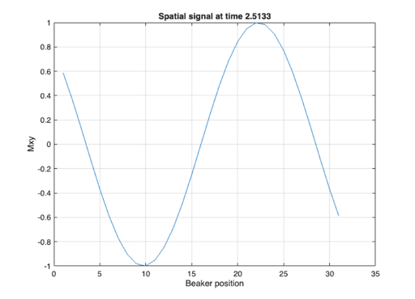

```matlab
mrvNewGraphWin;

% We read the signal at a point in time
thisT = 35;
plot(sig(:,thisT));
xlabel('Beaker position'); ylabel('Mxy');
grid on;
title('Spatial signal at time '+string(t(thisT)));
```

Now a little later in time

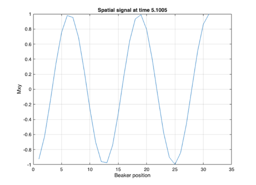

```matlab
mrvNewGraphWin;

thisT = 70;
plot(sig(:,thisT));
xlabel('Beaker position'); ylabel('Mxy'); grid on;
title('Spatial signal at time '+string(t(thisT)));
```

And later still

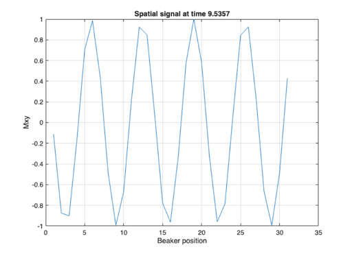

```matlab
mrvNewGraphWin;

thisT = 130;
plot(sig(:,thisT));
xlabel('Beaker position'); ylabel('Mxy'); grid on;
title('Spatial signal at time '+string(t(thisT)));
```

At each moment in time, the spatial distribution of signals is a sinusoid. Over time, as the signals evolve, the **spatial harmonic** that weights how much each beaker contributes to signal has a higher and higher spatial frequency! (Remember, the temporal frequency of each of the beakers is constant throughout this period when we will make the measurement.)

Remember all that stuff about the Fourier Series? Each of these values at a time looks like one of the terms in a Fourier Series!

1. What would happen if we use a stronger gradient (G)? Which variable would you change in the calculation?
2. How would you adjust the question to include a specification of the strength of the gradient, G?
3. How would a stronger gradient, left on for the same amount of time, affect the reconstructed image?

[Published with MATLAB® R2026a](https://www.mathworks.com/products/matlab/)